# Overview of retrieved datasets

**Script description:** This script manipulates the raw data of the retrieved datasets to show summary tables and figures.

**Script structure:**

1. Number of datasets and relevance categories.2. Queries performance - 3. Temporal duration - 4. Spatial range - 5. Temporal duration, spatial range, and relevance - 6. EBV data types - 7. Data format - 8. Datasets accessibility and relevance per year

(TODO)

9. Journals
10. Taxonomic coverage
11. Dataset location
12. Temporal and spatial information location

```r
library(ggrepel)
```

Some parameters for the plots:

```r
my.theme<-theme(axis.text=element_text(size=15),
        axis.title = element_text(size = 17),
        legend.text=element_text(size=10),
        legend.title = element_text(size=12),
        plot.title = element_text(face="bold",size=14,margin=margin(0,0,20,0),hjust = 0.5),
        axis.title.y = element_text(margin = margin(t = 0, r = 10, b = 0, l = 0)),
        axis.title.x = element_text(margin = margin(t = 15, r = 0, b = 0, l = 0)),
        panel.background = element_rect(fill = 'white'))
```

#### Read data

Eliminate empty rows and those where dataset_relevance is left in blank (they correspond to referred publications in the retrieved datasets and are not used in these analyses):

|  | url | title | description | method | notes | keywords | locations | publication_date | cited_articles | id_query | source | full_text | quebec | done | reason_non_valid | valid_yn | dataset_relevance | dataset_location | dataset_format | Geospatial_info_dataset | Geospatial_info_repo_page_text | Geospatial_info_article_text | species | temporal_range | temporal_range_position | temporal_duration_y | temporal_duration_position | spatial_range_km2 | spatial_range_position | … |
| --- | --- | --- | --- | --- | --- | --- | --- | --- | --- | --- | --- | --- | --- | --- | --- | --- | --- | --- | --- | --- | --- | --- | --- | --- | --- | --- | --- | --- | --- | --- |
| 1 | https://datadryad.org/stash/dataset/doi%3A10.5061%2Fdryad.8cz8w9gr1 | Data for the detection of the boreal chorus frog (Pseudacris maculata) using environmental DNA and call surveys at 180 ponds sampled in 2017-2018 in southeastern QuÃ©bec, Canada | The boreal chorus frog (Pseudacris maculata) is at risk of extinction in parts of its range in Canada. Our objectives were to quantify the influence of local and landscape characteristics on the occur… |  |  | Ecology, Herpetology, Landscape ecology |  | 13/9/2021 |  | 0 | dryad |  | NA | NA | NA | yes | M | repository | .csv | site IDs | no | Map, range coordinates | Pseudacris maculata | 2017-2018 | source link abstract, dataset | 1 | NA | 2250.00 | source publication text | … |
| 2 | https://datadryad.org/stash/dataset/doi%3A10.5061%2Fdryad.1771t | Data from: Resampling method for applying density-dependent habitat selection theory to wildlife surveys | Isodar theory can be used to evaluate fitness consequences of density-dependent habitat selection by animals. A typical habitat isodar is a regression curve plotting competitor densities in two adjace… |  |  | Wildlife survey_Procyon lotor_Mephitis mephitis_Striped skunk_Raccoon_capture |  | 7/5/2016 |  | 0 | dryad |  | NA | NA | NA | yes | M | repository | .xlsx | sample coordinates | region names | site coordinates | Racoon, striped skunks | 2008 | source publication text, dataset | <1 | no | 1700.00 | no | … |
| 3 | https://datadryad.org/stash/dataset/doi%3A10.5061%2Fdryad.rp77j | Data from: Strategies for a successful plant invasion: the reproduction of Phragmites australis in northeastern North America | 1. Knowing the relative contribution of vegetative propagation and sexual reproduction to the dispersal and establishment of exotic plants is crucial for devising efficient control strategies. This is… |  |  | genotyping-by-sequencing_Phragmites australis_road ecology_sexual reproduction_common reed_Invasion ecology_vegetative propagation_freshwater wetlands |  | 28/8/2016 |  | 0 | dryad |  | NA | NA | NA | yes | L | repository | .xlsx | site IDs | no | Map, geological feature name | Phragmites australis | 2009 | source publication text | <1 | NA | 416.00 | source publication text | … |
| 4 | https://datadryad.org/stash/dataset/doi%3A10.5061%2Fdryad.sf1k4m8 | Data from: Black spruce (Picea mariana) colonization of subarctic snowpatches in response to warmer climate | 1. Snowpatches are disjunct arctic ecosystems scattered across the Subarctic, particularly on wind-protected lee slopes, where a thick snow cover accumulates during the winter. These snow-rich treeles… |  |  | forest-tundra_plant-climate interactions_1950-2010_Holocene_treeline_tree-ring_Subarctic_Betula glandulosa_Picea mariana_snowpatch |  | 27/12/2018 |  | 0 | dryad |  | NA | NA | NA | yes | M | repository | .xlsx | site coordinates, IDs | no | Map | Black spruce, other 16 plants | 1960-2000 | source link abstract, dataset | 40 | no | 63.00 | no | … |
| 5 | https://datadryad.org/stash/dataset/doi%3A10.5061%2Fdryad.r6s1c | Data from: Continental divide: predicting climate-mediated fragmentation and biodiversity loss in the boreal forest | Climate change threatens natural landscapes through shifting distribution and abundance of species and attendant change in the structure and function of ecosystems. However, it remains unclear how cli… |  |  | Holocene |  | 25/4/2018 |  | 0 | dryad |  | NA | NA | NA | yes | H | repository | GeoTIFF | no | no | no | Dendragapus canadensis, Poecile hudsonicus, Alces americanus, Rangifer tarandus, other 8 mammals, 4 tree species, 3 bird species | 1950-2000 | source publication text | 50 | NA | 24706834.00 | source link abstract | … |
| 6 | https://datadryad.org/stash/dataset/doi%3A10.5061%2Fdryad.4767v | Data from: Ecological gradients driving the distribution of four Ericaceae in boreal Quebec, Canada | Understory species play a significant role in forest ecosystem dynamics. As such, species of the Ericaceae family have a major effect on the regeneration of tree species in boreal ecosystems. It is th… |  |  | Kalmia angustifolia_Anthropocene_redundancy analysis_Rhododendron groenlandicum_landscape ecology_Vaccinium angustifolium_Chamaedaphne calyculata_Vaccinium myrtilloides_ecological drivers |  | 11/3/2016 |  | 3 | dryad |  | NA | NA | NA | yes | H | repository | .csv | no | no | Map | Rhododendron groenlandicum, Kalmia angustifolia, Chamaedaphne calyculata, Vaccinium spp | 1980-2000 | source publication text | 20 | NA | 535355.00 | source link abstract, source publication text | … |

## 1. Number of datasets and relevance categories

```r
total_publications <- length(dataset$dataset_relevance)

print(paste("A total of", total_publications, "publications retrieved"))
```

```
[1] "A total of 292 publications retrieved"
```

```r
dataset$dataset_relevance <- as.factor(dataset$dataset_relevance)

df_N_relevance <- count_by_relevance(dataset)

df_N_relevance
```

[output not shown]

### 1.1 Relevance counts by source

|  | relevance | dryad | semantic_scholar | zenodo |
| --- | --- | --- | --- | --- |
| 3 | H | 10 | 3 | 11 |
| 5 | M | 13 | 21 | 21 |
| 4 | L | 16 | 29 | 24 |
| 1 | X | 11 | 16 | 29 |
| 6 | No dataset | 0 | 59 | 0 |
| 2 | cant access | 0 | 20 | 1 |

Plot the results:

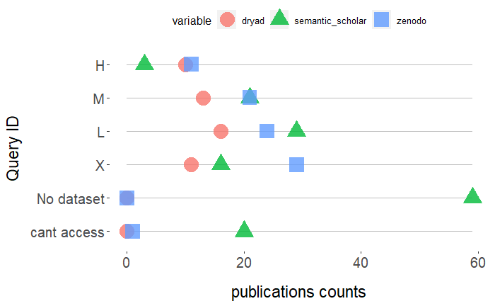

## 2. Queries performance

### 2.1. N publications and relevance categories per query

#### Grouped queries

```r
dataset$id_query <- as.factor(dataset$id_query)

df_queries_counts <- compute_df_n_relevance_queries(data = dataset)

df_queries_counts
```

|  | queries | n_publications | n_high | n_moderate | n_low | n_non_relevant | n_no_dataset |
| --- | --- | --- | --- | --- | --- | --- | --- |
| 1 | 0,6,5,7 | 1 | 0 | 0 | 0 | 0 | 0 |
| 2 | 1 | 12 | 0 | 1 | 2 | 7 | 2 |
| 3 | 10 | 8 | 1 | 3 | 3 | 0 | 0 |
| 4 | 2 | 11 | 0 | 1 | 4 | 1 | 4 |
| 5 | 3 | 52 | 10 | 10 | 15 | 14 | 0 |
| 6 | 4 | 69 | 5 | 14 | 18 | 1 | 19 |
| 7 | 5 | 21 | 1 | 5 | 3 | 0 | 5 |
| 8 | 5,6,7,8,9 | 1 | 0 | 1 | 0 | 0 | 0 |
| 9 | 6 | 32 | 1 | 8 | 10 | 0 | 8 |
| 10 | 6,7 | 1 | 0 | 1 | 0 | 0 | 0 |

[output cut: 7 more lines]

Plot the results:

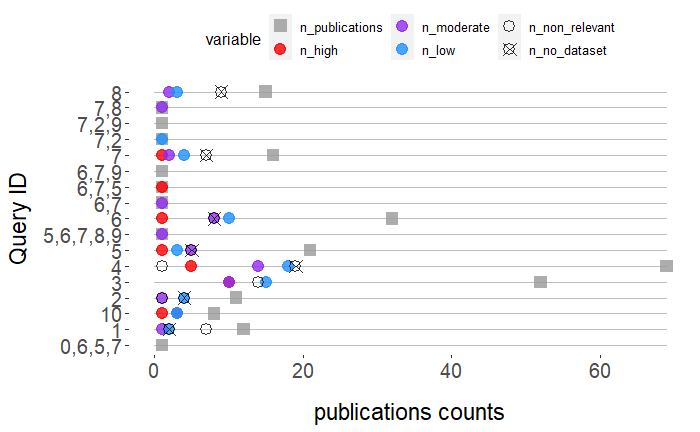

```r
plot_group.queries_relevance <- plot_queries_relevance_raw(df_queries_counts)

plot_group.queries_relevance
```

```r
#ggsave("plot_group.queries_relevance_all.png", height = 7, width = 12)
```

#### Individual queries

```r
#split rows in function of character comas

dataset_q <- dataset %>%
  separate_rows(id_query, sep=",")


dataset_q$id_query  <- as.factor(dataset_q$id_query)


df_queries_counts_ind <- compute_df_n_relevance_queries(data = dataset_q)

df_queries_counts_ind
```

|  | queries | n_publications | n_high | n_moderate | n_low | n_non_relevant | n_no_dataset |
| --- | --- | --- | --- | --- | --- | --- | --- |
| 1 | 1 | 12 | 0 | 1 | 2 | 7 | 2 |
| 2 | 10 | 8 | 1 | 3 | 3 | 0 | 0 |
| 3 | 2 | 13 | 0 | 1 | 5 | 1 | 4 |
| 4 | 3 | 52 | 10 | 10 | 15 | 14 | 0 |
| 5 | 4 | 69 | 5 | 14 | 18 | 1 | 19 |
| 6 | 5 | 24 | 2 | 6 | 3 | 0 | 5 |
| 7 | 6 | 37 | 2 | 10 | 10 | 0 | 8 |
| 8 | 7 | 24 | 2 | 5 | 5 | 0 | 7 |
| 9 | 8 | 17 | 0 | 4 | 3 | 0 | 9 |
| 10 | 9 | 3 | 0 | 1 | 0 | 0 | 0 |

Plot the results

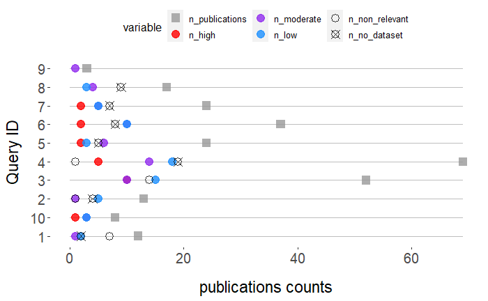

```r
plot_ind.queries_relevance_ind <- plot_queries_relevance_raw(df_queries_counts_ind)

plot_ind.queries_relevance_ind
```

```r
#ggsave("plot_ind.queries_relevance_all.png", height = 7, width = 12)
```

### 2.2 Classify queries by their relevance (index)

Puctuations for the relevance categories:

- High = 5
- Mod = 2
- Low = 0.5
- non_relevant = 0

*Index 1*: is the result of summing the puntuations assigned to each relevance category

Index 1 = sum punctuations = (N High * 5) + (N Mod * 2) + (N Low * 0.5)

*Index 2*: is the Index1 but accounting for the total number of publications retrieved by the query.

Index 2 = sum punctuations / n publications retrieved

#### Grouped queries

```r
df_queries_counts_index <- compute_index12(df_counts = df_queries_counts, order_based_index = "2") # "1" for ordering according to index 1, "2" for index 2

df_queries_counts_index
```

|  | queries | n_publications | n_high | n_moderate | n_low | n_non_relevant | n_no_dataset | index1 | index2 |
| --- | --- | --- | --- | --- | --- | --- | --- | --- | --- |
| 11 | 6,7,5 | 1 | 1 | 0 | 0 | 0 | 0 | 5.0 | 5.0000000 |
| 8 | 5,6,7,8,9 | 1 | 0 | 1 | 0 | 0 | 0 | 2.0 | 2.0000000 |
| 10 | 6,7 | 1 | 0 | 1 | 0 | 0 | 0 | 2.0 | 2.0000000 |
| 16 | 7,8 | 1 | 0 | 1 | 0 | 0 | 0 | 2.0 | 2.0000000 |
| 3 | 10 | 8 | 1 | 3 | 3 | 0 | 0 | 12.5 | 1.5625000 |
| 5 | 3 | 52 | 10 | 10 | 15 | 14 | 0 | 77.5 | 1.4903846 |
| 6 | 4 | 69 | 5 | 14 | 18 | 1 | 19 | 62.0 | 0.8985507 |
| 9 | 6 | 32 | 1 | 8 | 10 | 0 | 8 | 26.0 | 0.8125000 |
| 7 | 5 | 21 | 1 | 5 | 3 | 0 | 5 | 16.5 | 0.7857143 |
| 13 | 7 | 16 | 1 | 2 | 4 | 0 | 7 | 11.0 | 0.6875000 |

[output cut: 7 more lines]

```r
NA
```

Plot the results:

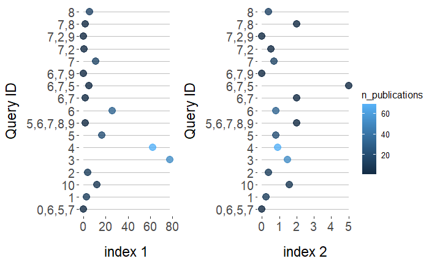

```r
plot_group.queries_index12 <- plot_queries_index(df = df_queries_counts_index)

plot_group.queries_index12
```

```r
#ggsave("plot_group.queries_index12.png", height = 5, width = 11)
```

- Index 1 shows that queries “3” and “4” offer the higher perfomance, followed by “6” and “5”.
- Index 2 shows that querie “6,7,5” offer the highest performance, followed by “7,8”, “6,7”, and “5,6,7,8,9”

#### individual queries

```r
df_queries_counts_index_ind <- compute_index12(df_counts = df_queries_counts_ind, order_based_index = "2") # "1" for ordering according to index 1, "2" for index 2

df_queries_counts_index_ind
```

|  | queries | n_publications | n_high | n_moderate | n_low | n_non_relevant | n_no_dataset | index1 | index2 |
| --- | --- | --- | --- | --- | --- | --- | --- | --- | --- |
| 2 | 10 | 8 | 1 | 3 | 3 | 0 | 0 | 12.5 | 1.5625000 |
| 4 | 3 | 52 | 10 | 10 | 15 | 14 | 0 | 77.5 | 1.4903846 |
| 6 | 5 | 24 | 2 | 6 | 3 | 0 | 5 | 23.5 | 0.9791667 |
| 7 | 6 | 37 | 2 | 10 | 10 | 0 | 8 | 35.0 | 0.9459459 |
| 8 | 7 | 24 | 2 | 5 | 5 | 0 | 7 | 22.5 | 0.9375000 |
| 5 | 4 | 69 | 5 | 14 | 18 | 1 | 19 | 62.0 | 0.8985507 |
| 10 | 9 | 3 | 0 | 1 | 0 | 0 | 0 | 2.0 | 0.6666667 |
| 9 | 8 | 17 | 0 | 4 | 3 | 0 | 9 | 9.5 | 0.5588235 |
| 3 | 2 | 13 | 0 | 1 | 5 | 1 | 4 | 4.5 | 0.3461538 |
| 1 | 1 | 12 | 0 | 1 | 2 | 7 | 2 | 3.0 | 0.2500000 |

Plot the results

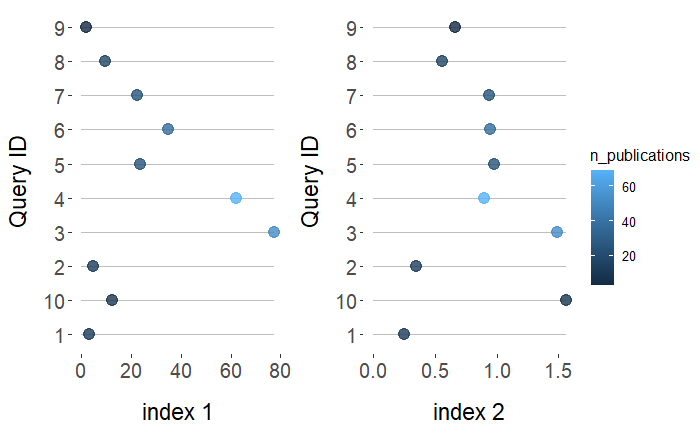

```r
plot_queries_index12_ind <- plot_queries_index(df = df_queries_counts_index_ind)

plot_queries_index12_ind
```

```r
#ggsave("plot_ind.queries_index12.png", height = 5, width = 11)
```

### 2.3. F SCORE

Precision Recall

Binary view: M,H relevant | L,X unrevelant

N relevant datasets -> True Positives (TP)

N unrelevant datasets -> False Positives (FP)

Sum of all relevant publications of the dataset that are not detected = FN

PRECISION = TP / TP + FP

RECALL = TP / TP + FN

F SCORE = 2* precision * recall / precision + recall

Split grouped queries into individual ones

|  | queries | Fscore | Precision | Recall |
| --- | --- | --- | --- | --- |
| 6 | 4 | 0.25503356 | 0.30645161 | 0.21839080 |
| 5 | 3 | 0.25157233 | 0.27777778 | 0.22988506 |
| 8 | 6 | 0.19047619 | 0.30769231 | 0.13793103 |
| 1 | 0 | 0.15625000 | 0.24390244 | 0.11494253 |
| 7 | 5 | 0.14678899 | 0.36363636 | 0.09195402 |
| 9 | 7 | 0.12612613 | 0.29166667 | 0.08045977 |
| 10 | 8 | 0.08163265 | 0.36363636 | 0.04597701 |
| 3 | 10 | 0.08080808 | 0.33333333 | 0.04597701 |
| 11 | 9 | 0.02197802 | 0.25000000 | 0.01149425 |
| 4 | 2 | 0.02083333 | 0.11111111 | 0.01149425 |

[output cut: 1 more lines]

Plot results

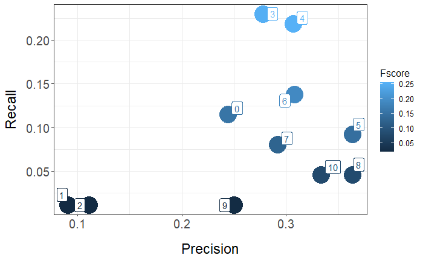

```r
plot_queries_scores <- ggplot(df_zscores_queries, aes(x = Precision, y = Recall, colour = Fscore)) +
  geom_point(size = 10)+
  geom_label_repel(aes(label = queries))+
  theme_bw()+
  my.theme

plot_queries_scores
```

```r
#ggsave("plot_queries_scores.png", height = 7, width = 7)
```

## 3. Temporal duration

### 3.1 Temporal duration counts

How many publications without temporal duration data?

```r
nNa <- count_not.reported_temporal.duration(dataset)
print(paste(nNa, "publications without temporal duration data"))
```

```
[1] "33 publications without temporal duration data"
```

Publication counts by temporal duration (years):

```r
df_duration_counts <- count_durations(df = dataset, order_by = "counts")
df_duration_counts
```

|  | temporal_duration | counts |
| --- | --- | --- |
| 1 | 1 | 23 |
| 2 | 2 | 12 |
| 6 | 6 | 7 |
| 3 | 3 | 6 |
| 4 | 4 | 5 |
| 7 | 7 | 3 |
| 18 | 20 | 3 |
| 8 | 8 | 2 |
| 9 | 9 | 2 |
| 10 | 10 | 2 |

[output cut: 18 more lines]

Plot the results:

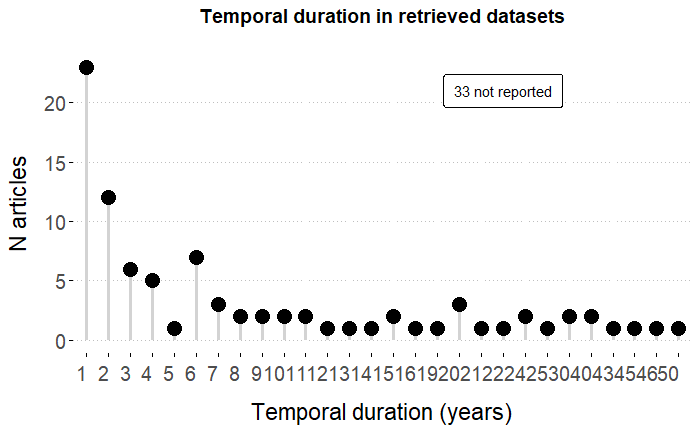

```r
plot_temp_duration <- plot_duration_counts(df = df_duration_counts,
                                           counts_Na = nNa)

plot_temp_duration
```

```r
#ggsave("plot_temp_duration.png", height = 7, width = 12)
```

Average duration (for those with data):

```r
dataset_temp_duration <- subset(dataset,
                                  temporal_duration_y > 0 | temporal_duration_y == "no",
                                  select = c(temporal_duration_y,id_query))

  dataset_temp_duration$temporal_duration_y <- as.numeric(dataset_temp_duration$temporal_duration_y)
print(paste("mean of",
            round(mean(na.omit(dataset_temp_duration$temporal_duration_y)),digits = 1),
            "years"))
```

```
[1] "mean of 9.5 years"
```

### 3.1 Temporal duration counts per relevance category

[output not shown]

[figure not shown]

```r
plot_duration_relevance.categories
```

## 4. Spatial range

### 4.1 count spatial range publications

WARNING: publications that cant be accessed are not counted

How many publications without spatial range data?

```r
n_not_reported <- count_not.reported_spatial_range(dataset)

print(paste(n_not_reported, "publications without spatial range data"))
```

```
[1] "46 publications without spatial range data"
```

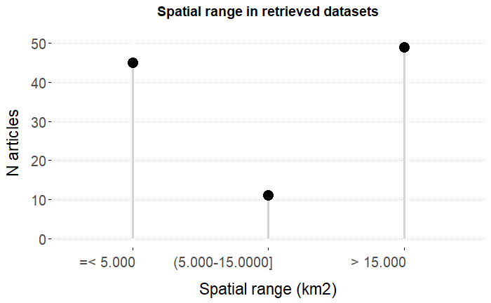

```r
plot_spatial_range_counts <- plot_spat.range_counts(dataset)
plot_spatial_range_counts
```

```r
#ggsave("plot_spatial_range_counts.png", height = 7, width = 7)
```

Average spatial range (for those with data):

```r
dataset1 <- dataset[dataset$dataset_relevance != "cant access",]

  dataset1$dataset_relevance <- as.factor(dataset1$dataset_relevance)

  spatial_range_km2_vec <- dataset1$spatial_range_km2[dataset1$spatial_range_km2 != ""]

  spatial_range_km2_vec <- spatial_range_km2_vec[!is.na(spatial_range_km2_vec)]

  spatial_range_km2_vec <- as.numeric(spatial_range_km2_vec)
print(paste("mean of",
            round(mean(na.omit(spatial_range_km2_vec)), digits = 0),
            "km2"))
```

```
[1] "mean of 973065 km2"
```

## 5. Temporal duration, spatial range, relevance

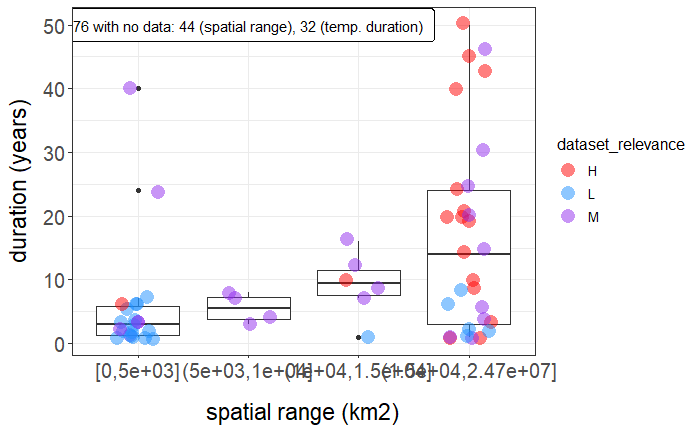

```r
plot_spatial_temporal_relevance <- plot_spat_temp_relevance(df = dataset)
plot_spatial_temporal_relevance
```

```r
#ggsave("plot_spatial_temporal_relevance.png", height = 7, width = 9)
```

## 6. EBV data types

```r
df_data_type_counts <- compute_df_data.type(df = dataset)

df_data_type_counts
```

| data_type_col | N_articles | percentage |
| --- | --- | --- |
| presence.only | 62 | 32.6315789 |
| presence.absence | 15 | 7.8947368 |
| abundance | 59 | 31.0526316 |
| EBV_genetic | 29 | 15.2631579 |
| genetic_analyses | 1 | 0.5263158 |
| distribution | 4 | 2.1052632 |
| other | 20 | 10.5263158 |

```r
NA
```

Plot the results

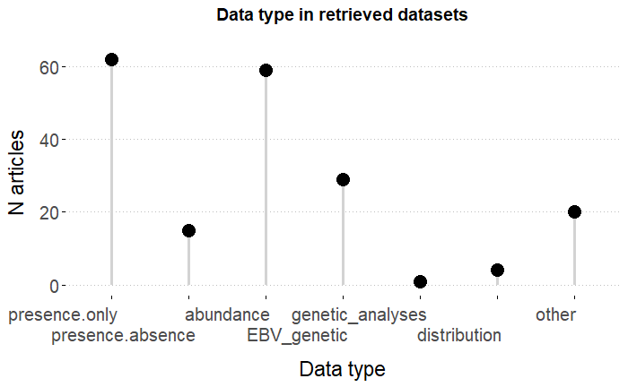

```r
plot_data_type <- plot_data.type_counts(df_data_type_counts)

plot_data_type
```

```r
#ggsave("plot_data_type.png", height = 7, width = 9)
```

## 7. Data format

Those datasets in the repository that are relevance category X don’t have format information.

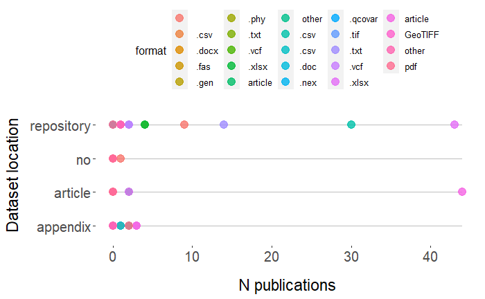

```r
plot_data_format_counts <- plot_data.type_format(dataset)

plot_data_format_counts
```

```r
#ggsave("plot_data_format_counts.png", height = 7, width = 9)
```

## 8. Datasets accessibility and relevance per year

Raw plot relevance per year

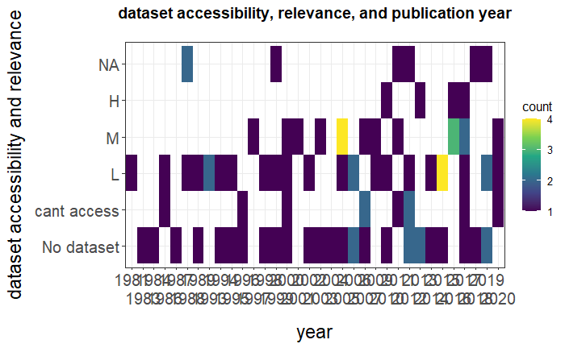

```r
plot_relevance_access_year <- plot_relevance_year(dataset)

plot_relevance_access_year
```

```r
#ggsave("plot_relevance_access_year.png", height = 7, width = 14)
```

Relevance per year (intervals):

```r
df_relevance_year.range <- compute_df_relevance_year.range(dataset)

df_relevance_year.range
```

| dataset relevance | publication year | Publication counts |
| --- | --- | --- |
|  | [0,1.99e+03] | 0 |
| No dataset | [0,1.99e+03] | 4 |
| cant access | [0,1.99e+03] | 1 |
| X | [0,1.99e+03] | 2 |
| L | [0,1.99e+03] | 4 |
| M | [0,1.99e+03] | 0 |
| H | [0,1.99e+03] | 0 |
|  | (1.99e+03,2e+03] | 0 |
| No dataset | (1.99e+03,2e+03] | 6 |
| cant access | (1.99e+03,2e+03] | 2 |

[output cut: 18 more lines]

```r
NA
```

Plot the results:

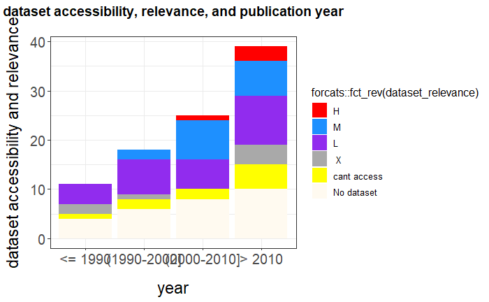

```r
plot_relevance_year.range <- plot_relevance_year.range(dataset)

plot_relevance_year.range
```

```r
#ggsave("plot_relevance_year.range.png", height = 7, width = 9)
```

## 9. Journals

Count publications per journal

```r
dataset.j <- dataset[dataset$Journal != "" & dataset$Journal != "no",]

df_journals_counts <- as.data.frame(table(dataset.j$Journal))

colnames(df_journals_counts) = c("Journal", "Publication_counts")

df_journals_counts <- df_journals_counts[order(-df_journals_counts$Publication_counts),]


df_journals_counts
```

|  | Journal | Publication_counts |
| --- | --- | --- |
| 31 | Ecology and Evolution | 14 |
| 76 | Molecular Ecology | 12 |
| 88 | Plos One | 11 |
| 58 | Journal of Applied Ecology | 10 |
| 14 | BioOne | 8 |
| 19 | Canadian Journal of Forest Research | 8 |
| 63 | Journal of Ecology | 7 |
| 41 | Evolutionary Applications | 6 |
| 17 | Canadian Journal of Botany | 5 |
| 29 | Ecology | 5 |

[output cut: 96 more lines]

```r
NA
NA
```

```r
print(paste("A total of", length(df_journals_counts$Journal), "journals" ))
```

```
[1] "A total of 106 journals"
```

## 10. Source of information across time

|  | publication_date | source | year |
| --- | --- | --- | --- |
| 2 | 7/5/2016 | dryad | 2016 |
| 3 | 28/8/2016 | dryad | 2016 |
| 4 | 27/12/2018 | dryad | 2018 |
| 5 | 25/4/2018 | dryad | 2018 |
| 6 | 11/3/2016 | dryad | 2016 |
| 7 | 1/6/2018 | dryad | 2018 |
| 8 | 13/8/2015 | dryad | 2015 |
| 9 | 17/3/2015 | dryad | 2015 |
| 10 | 19/6/2018 | dryad | 2018 |
| 11 | 17/3/2015 | dryad | 2015 |

[output cut: 273 more lines]

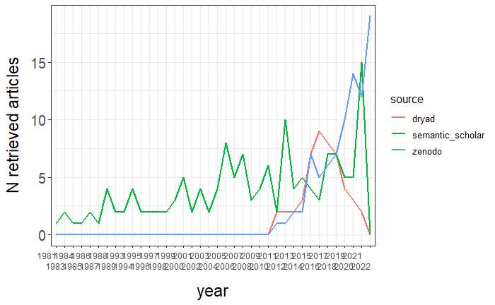

```r
df_plot_source_time <- as.data.frame(table(df.source_time$year,df.source_time$source ))

colnames(df_plot_source_time) <- c("year", "source", "N")

df_plot_source_time$N <- as.numeric(df_plot_source_time$N)


plot_source_time <- ggplot(df_plot_source_time, aes(x = year, y = N, group = source, color = source)) +
  geom_line(size = 1)+
    theme_bw()+
  my.theme+
  theme(axis.text.x = element_text(angle = 0, hjust=0.95,vjust=0.2, size = 9))+
  ylab("N retrieved articles") +
  scale_x_discrete(guide = guide_axis(n.dodge=2))

plot_source_time
```

```r
#ggsave("plot_source_time.png", height = 7, width = 13)
```

## 10. Location of information

```r
df_location_info <- compute_df_location_info(df = dataset)
```

[figure not shown]

```r
df_plot_loc_spatial.range <- df_location_info[df_location_info$spatial_range_position != "",]

df_plot_loc_temporal.range <- df_location_info[df_location_info$temporal_range_position != "",]

df_plot_loc_temporal.duration <- df_location_info[df_location_info$temporal_duration_position != "",]



plot_spat_range_position <- ggplot(na.omit(df_plot_loc_spatial.range), aes(x=spatial_range_position, fill = dataset_location)) +
  geom_bar(aes(y = (..count..))) +
  geom_text(stat='count', aes(label=..count..),position = position_stack(vjust = 0.5))+
  ggtitle("Spatial range information")+
  theme_bw()+
  my.theme+
  theme(axis.text.x = element_text(angle = 0, hjust=0.95,vjust=0.2, size = 9))+
  ylab("N retrieved articles") +
  scale_x_discrete(guide = guide_axis(n.dodge=2))


plot_temp_range_position <- ggplot(na.omit(df_plot_loc_temporal.range), aes(x=temporal_range_position, fill = dataset_location)) +
  geom_bar(aes(y = (..count..))) +
  geom_text(stat='count', aes(label=..count..),position = position_stack(vjust = 0.5))+
    ggtitle("Temporal range information")+
  theme_bw()+
  my.theme+
  theme(axis.text.x = element_text(angle = 0, hjust=0.95,vjust=0.2, size = 9))+
  ylab("N retrieved articles") +
  scale_x_discrete(guide = guide_axis(n.dodge=2))


df_plot_loc_temporal.duration <- ggplot(na.omit(df_plot_loc_temporal.duration), aes(x=temporal_duration_position, fill = dataset_location)) +
  geom_bar(aes(y = (..count..))) +
  geom_text(stat='count', aes(label=..count..),position = position_stack(vjust = 0.5))+
  ggtitle("Temporal duration information")+
  theme_bw()+
  my.theme+
  theme(axis.text.x = element_text(angle = 0, hjust=0.95,vjust=0.2, size = 9))+
  ylab("N retrieved articles") +
  scale_x_discrete(guide = guide_axis(n.dodge=2))


plot_location_spatiotemporal_information <- ggarrange(plot_spat_range_position,
          plot_temp_range_position,
          df_plot_loc_temporal.duration,
          ncol = 1,
          nrow = 3,
          common.legend = TRUE,
          legend = "top")
plot_location_spatiotemporal_information
```

```r
#ggsave("plot_location_spatiotemporal_information.png", height = 16, width = 7)
```

# location - dataset type

We evaluate the feasibility to automatically retrieve the information on the dataset type by looking at whether authors make explicit the type of dataset in either the title or abstract.

Type of dataset should fall in one of the following categories or synonyms:

```r
df_dataset_types <- read.csv("../data/dataset_types.csv", sep = ";")
df_dataset_types
```

| type_dataset | keywords | keywords_type |
| --- | --- | --- |
| presence only | presence only | synonym |
| presence only | occurrence | synonym |
| presence only | specimen records | synonym |
| presence only | specimen | synonym |
| presence only | collection | synonym |
| presence-absence | presence-absence | synonym |
| presence-absence | sampling plot | methods |
| presence-absence | relative proportion | methods |
| presence-absence | inventory | methods |
| presence-absence | occupancy | methods |

[output cut: 16 more lines]

I will add the following synonyms:

presence-absence: detection, capture

EBV genetic analyses: 16S, 18S, genetic data, microsatelites, barcodes(?), haplotypes, eDNA, SNPs

```r
df_dataset_types[nrow(df_dataset_types)+1,] <- c("presence-absence", "detection", "synonym")
df_dataset_types[nrow(df_dataset_types)+1,] <- c("presence-absence", "capture", "synonym")

df_dataset_types[nrow(df_dataset_types)+1,] <- c("EBV genetic analyses", "16S", "methods")
df_dataset_types[nrow(df_dataset_types)+1,] <- c("EBV genetic analyses", "18S", "methods")
df_dataset_types[nrow(df_dataset_types)+1,] <- c("EBV genetic analyses", "barcodes", "methods")
df_dataset_types[nrow(df_dataset_types)+1,] <- c("EBV genetic analyses", "haplotypes", "methods")
df_dataset_types[nrow(df_dataset_types)+1,] <- c("EBV genetic analyses", "eDNA", "methods")
df_dataset_types[nrow(df_dataset_types)+1,] <- c("EBV genetic analyses", "SNPs", "methods")

df_dataset_types
```

|  | type_dataset | keywords | keywords_type |
| --- | --- | --- | --- |
| 1 | presence only | presence only | synonym |
| 2 | presence only | occurrence | synonym |
| 3 | presence only | specimen records | synonym |
| 4 | presence only | specimen | synonym |
| 5 | presence only | collection | synonym |
| 6 | presence-absence | presence-absence | synonym |
| 7 | presence-absence | sampling plot | methods |
| 8 | presence-absence | relative proportion | methods |
| 9 | presence-absence | inventory | methods |
| 10 | presence-absence | occupancy | methods |

[output cut: 24 more lines]

Detecting the words in title or abstract

|  | url | dataset_type | in_abstract | in_title | keyword_abs |
| --- | --- | --- | --- | --- | --- |
| 1 | https://datadryad.org/stash/dataset/doi%3A10.5061%2Fdryad.8cz8w9gr1 | presence-absence | yes | yes |  |
| 2 | https://datadryad.org/stash/dataset/doi%3A10.5061%2Fdryad.1771t | presence-absence | yes | yes |  |
| 3 | https://datadryad.org/stash/dataset/doi%3A10.5061%2Fdryad.rp77j | EBV genetic analysis | yes | no |  |
| 4 | https://datadryad.org/stash/dataset/doi%3A10.5061%2Fdryad.sf1k4m8 | presence-absence, density | no | no |  |
| 5 | https://datadryad.org/stash/dataset/doi%3A10.5061%2Fdryad.r6s1c | distribution | yes | no |  |
| 6 | https://datadryad.org/stash/dataset/doi%3A10.5061%2Fdryad.4767v | abundance | yes | yes |  |
| 7 | https://datadryad.org/stash/dataset/doi%3A10.5061%2Fdryad.5ff8m0q | genetic analysis | no | no |  |
| 8 | https://datadryad.org/stash/dataset/doi%3A10.5061%2Fdryad.qt30h | abundance (percent cover) | no | no |  |
| 9 | https://datadryad.org/stash/dataset/doi%3A10.5061%2Fdryad.63fr7 | EBV genetic analysis, other | no | no |  |
| 10 | https://datadryad.org/stash/dataset/doi%3A10.5061%2Fdryad.7tn01 | other | yes | no |  |

[output cut: 158 more lines]

For some reason, keyword_title has 3 less entries that keyword_abstract, and I can’t figure out why. So for now I cant obtain the list of words that appear in the title.

```r
print(paste(length(which(df_data_type_abs1$in_abstract == "yes")),
            "with dataset type or synonym explicit in the abstract, out of", length(df_data_type_abs1$in_abstract)))
```

```
[1] "131 with dataset type or synonym explicit in the abstract, out of 168"
```

```r
print(paste("so",
      round(length(which(df_data_type_abs1$in_abstract == "yes"))/length(df_data_type_abs1$in_abstract)*100, 1),
"%"))
```

```
[1] "so 78 %"
```

```r
print(paste(length(which(df_data_type_abs1$in_title == "yes")),
            "with dataset type or synonym explicit in the title, out of", length(df_data_type_abs1$in_title)))
```

```
[1] "34 with dataset type or synonym explicit in the title, out of 168"
```

```r
print(paste("so",
      round(length(which(df_data_type_abs1$in_title == "yes"))/length(df_data_type_abs1$in_title)*100, 1),
"%"))
```

```
[1] "so 20.2 %"
```